# Predicting Daily Bike Traffic Across a Bridge

Sean Schilk

11/2/2025

We will be doing a Poisson Regression Modeling example here. The dataset was provided in class

The daily total of bike counts was conducted monthly on the Brooklyn Bridge, Manhattan Bridge, Williamsburg Bridge, and Queensboro Bridge. To keep count of cyclists entering and leaving Queens, Manhattan, and Brooklyn via the East River Bridges. The Traffic Information Management System (TIMS) collects the count data. Each record represents the total number of cyclists per 24 hours at Brooklyn Bridge, Manhattan Bridge, Williamsburg Bridge, and Queensboro Bridge.

```r
# You need to use library {openxlsx} to read the excel file
library(openxlsx)
id=sample(1:10, 1)
dat <- read.xlsx("https://pengdsci.github.io/STA321/ww09/w09-AssignDataSet.xlsx", sheet = paste("data",9, sep = "")) # we got data set 9

# You should replace my local folder path 'C:\\Users\\75CPENG\\Downloads\\'
# with yours
# write.csv(dat, paste("~/STA321/Redo/W9-PoissonReg/",names(dat[6]), ".csv", sep=""))
# Go to your folder to load your data set (.csv) to your GitHub repository and
# Read the data to your R directly to R so I can run your RMD source on my machine!
```

# 1 Poisson Regression on Bike Counts

First we do some EDA. We don’t need Date variable, as its an obs ID variable.

```r
biking <- dat # create a copy of the data set
biking$Date <- NULL

#Transform Day from numeric to categorical
biking$Day <- as.Date(biking$Day, origin = "1899-12-30")
biking$Day <- weekdays(biking$Day)

head(biking)
```

```
##         Day HighTemp LowTemp Precipitation BrooklynBridge Total
## 1    Sunday     66.9    50.0             0           2297 15975
## 2    Monday     72.0    52.0             0           3387 23784
## 3   Tuesday     70.0    57.0             0           3386 25280
## 4 Wednesday     75.0    55.9             0           3412 25477
## 5  Thursday     82.0    64.9             0           3312 23942
## 6    Friday     81.0    69.1             0           2982 22197
```

We first build a Poisson frequency regression model and ignore the total bike counts for all bridges

```r
library(knitr)
model.freq <- glm(BrooklynBridge ~ Day + HighTemp + LowTemp + Precipitation, family = poisson(link = "log"), data = biking)
##
pois.count.coef = summary(model.freq)$coef
kable(pois.count.coef, caption = "The Poisson regression model for the counts of bike crossings versus the predictors")
```

The Poisson regression model for the counts of bike crossings versus the predictors

|  | Estimate | Std. Error | z value | Pr(>\|z\|) |
| --- | --- | --- | --- | --- |
| (Intercept) | 7.6104726 | 0.0350946 | 216.8557990 | 0.0000000 |
| DayMonday | -0.0714748 | 0.0134484 | -5.3147565 | 0.0000001 |
| DaySaturday | -0.2380188 | 0.0138770 | -17.1520035 | 0.0000000 |
| DaySunday | -0.2405215 | 0.0143571 | -16.7527596 | 0.0000000 |
| DayThursday | 0.0296039 | 0.0131038 | 2.2591821 | 0.0238721 |
| DayTuesday | -0.0010931 | 0.0126019 | -0.0867439 | 0.9308751 |
| DayWednesday | 0.0436535 | 0.0127947 | 3.4118414 | 0.0006453 |
| HighTemp | 0.0220248 | 0.0008560 | 25.7308060 | 0.0000000 |
| LowTemp | -0.0200883 | 0.0008834 | -22.7409443 | 0.0000000 |
| Precipitation | -1.4864054 | 0.0506009 | -29.3750554 | 0.0000000 |

The above inferential table about the regression coefficients indicates significance for every predictor except DayTuesday. Comparing to our baseline DayFriday, each day yields less bike crossings, other than Thursday and Wednesday were there are more.

# 2 Poisson Regression on Rates

The following model assesses the potential relationship between bike crossing rates and Day of the week.

```r
model.rates <- glm(BrooklynBridge ~ Day + HighTemp + LowTemp + Precipitation,
                   offset = log(Total),
                   family = poisson(link = "log"),
                   data = biking)
kable(summary(model.rates)$coef, caption = "Poisson regression on the rate of the
      the bike crossing rate across days of the week")
```

Poisson regression on the rate of the the bike crossing rate across days of the week

|  | Estimate | Std. Error | z value | Pr(>\|z\|) |
| --- | --- | --- | --- | --- |
| (Intercept) | -1.8782777 | 0.0353287 | -53.1657605 | 0.0000000 |
| DayMonday | -0.0290109 | 0.0131078 | -2.2132605 | 0.0268797 |
| DaySaturday | 0.0101480 | 0.0138468 | 0.7328773 | 0.4636333 |
| DaySunday | 0.0534409 | 0.0143345 | 3.7281271 | 0.0001929 |
| DayThursday | -0.0298994 | 0.0131118 | -2.2803399 | 0.0225875 |
| DayTuesday | -0.0270614 | 0.0125364 | -2.1586255 | 0.0308792 |
| DayWednesday | -0.0239583 | 0.0127221 | -1.8831975 | 0.0596736 |
| HighTemp | 0.0019344 | 0.0008161 | 2.3701500 | 0.0177809 |
| LowTemp | -0.0037133 | 0.0008384 | -4.4288199 | 0.0000095 |
| Precipitation | -0.3240410 | 0.0259998 | -12.4632219 | 0.0000000 |

The above table indicates that the log of bike crossing rate is not identical across the days of the week. To be specific, the log rates of the baseline day of Friday were lower than the weekend, but higher than the weekdays. The lowest log rate was Thursday.

```r
model.rates <- glm(BrooklynBridge ~ Day + LowTemp + HighTemp + Precipitation,
                   offset = log(Total),
                   family = quasipoisson,
                   data = biking)
summary(model.rates)
```

```
##
## Call:
## glm(formula = BrooklynBridge ~ Day + LowTemp + HighTemp + Precipitation,
##     family = quasipoisson, data = biking, offset = log(Total))
##
## Coefficients:
##                Estimate Std. Error t value Pr(>|t|)
## (Intercept)   -1.878278   0.111521 -16.842 1.13e-13 ***
## DayMonday     -0.029011   0.041377  -0.701 0.490915
## DaySaturday    0.010148   0.043710   0.232 0.818656
## DaySunday      0.053441   0.045249   1.181 0.250795
## DayThursday   -0.029899   0.041390  -0.722 0.478025
## DayTuesday    -0.027061   0.039573  -0.684 0.501560
## DayWednesday  -0.023958   0.040160  -0.597 0.557168
## LowTemp       -0.003713   0.002647  -1.403 0.175230
## HighTemp       0.001934   0.002576   0.751 0.461082
## Precipitation -0.324041   0.082073  -3.948 0.000735 ***
## ---
## Signif. codes:  0 '***' 0.001 '**' 0.01 '*' 0.05 '.' 0.1 ' ' 1
##
## (Dispersion parameter for quasipoisson family taken to be 9.96462)
##
##     Null deviance: 525.40  on 30  degrees of freedom
## Residual deviance: 212.55  on 21  degrees of freedom
## AIC: NA
##
## Number of Fisher Scoring iterations: 4
```

Here we can see our coefficient estimates stayed the same, but pvalues changed. The intercept represents the baseline log bike rate ( For Friday ). The actual rate is exp(-1.878278) = 15.29%. The coefficient -0.029011 is the difference of the log rates between baseline day Friday and day of the week Monday, holding all other variables constant, which is equivalent to 0.9714058. This means, holding all other variables constant, the bike rates are about (1-0.9714058) = 2.86% lower on Mondays than on Fridays.

# 3 Grahpical Comparison

The inferential tables of the Poisson regression models in the previous sections give numerical information about the potential discrepancy across the days of the week. But it is not intuitive. Next, we create a graphic to visualize the relationship between bike crossing rate and days of the week.

We can first write out the rate model as
$$\hat{rate} = \exp(-1.878278 - 0.029011 \times
\text{DayMonday} + 0.010148 \times \text{DaySaturday} + 0.053441 \times
\text{DaySunday} - 0.029899 \times \text{DayThursday} - 0.027061 \times
\text{DayTuesday} - 0.023958 \times \text{DayWednesday}) \times
\exp(0.001934 \times \text{HighTemp} - 0.003713 \times \text{LowTemp} -
0.324041 \times \text{Precipitation})$$

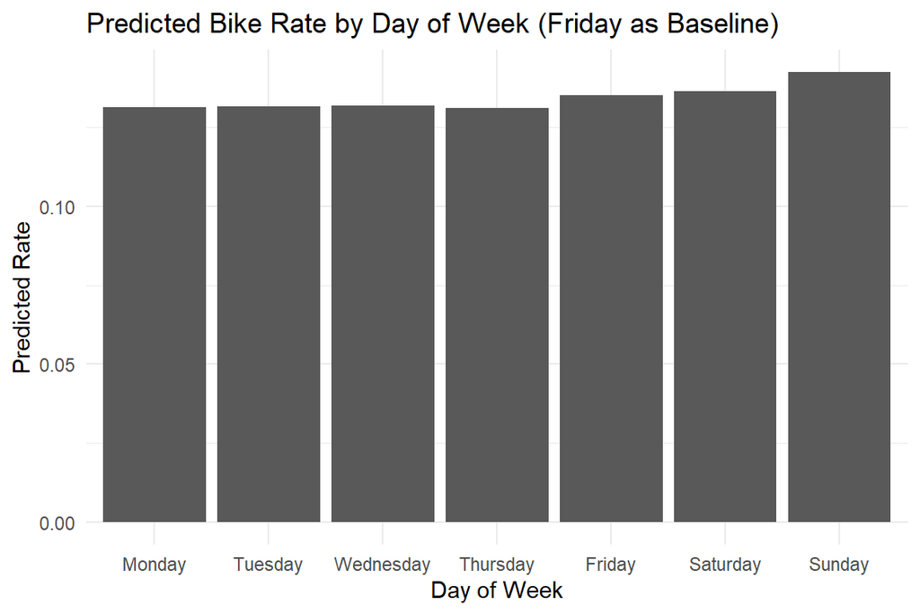

```r
library(ggplot2)

# 1. Baseline weather (hold constant)
HighTemp <- mean(biking$HighTemp, na.rm = TRUE)
LowTemp <- mean(biking$LowTemp, na.rm = TRUE)
Precipitation <- mean(biking$Precipitation, na.rm = TRUE)

# 2. Create day-of-week dataset (Friday is baseline: all dummies = 0)
days_df <- data.frame(
  Day = c("Monday","Tuesday","Wednesday","Thursday","Friday","Saturday","Sunday"),

  DayMonday = c(1,0,0,0,0,0,0),
  DayTuesday = c(0,1,0,0,0,0,0),
  DayWednesday = c(0,0,1,0,0,0,0),
  DayThursday = c(0,0,0,1,0,0,0),
  DaySaturday = c(0,0,0,0,0,1,0),
  DaySunday = c(0,0,0,0,0,0,1),

  HighTemp = HighTemp,
  LowTemp = LowTemp,
  Precipitation = Precipitation
)

# 3. Compute predicted rate
days_df$rate <- exp(
  -1.878278 +
    (-0.029011 * days_df$DayMonday) +
    (0.010148 * days_df$DaySaturday) +
    (0.053441 * days_df$DaySunday) +
    (-0.029899 * days_df$DayThursday) +
    (-0.027061 * days_df$DayTuesday) +
    (-0.023958 * days_df$DayWednesday) +
    (0.001934 * days_df$HighTemp) +
    (-0.003713 * days_df$LowTemp) +
    (-0.324041 * days_df$Precipitation)
)

# 4. Plot (order days properly)
days_df$Day <- factor(days_df$Day,
                      levels = c("Monday","Tuesday","Wednesday","Thursday","Friday","Saturday","Sunday"))

ggplot(days_df, aes(x = Day, y = rate)) +
  geom_col() +
  labs(
    title = "Predicted Bike Rate by Day of Week (Friday as Baseline)",
    x = "Day of Week",
    y = "Predicted Rate"
  ) +
  theme_minimal()
```

# 4 Concluding Remarks